# ABCDv5.1 Longitudinal depRS

2025-03-17

# Elastic net linear regression using ‘glmnet’

Model predicting year 2 CBCL using environmental factors measured at baseline.

## Data prep

N = 8975 individuals with CBCL data at year 2

Total N = 7033 split into training 80/% (N = 5625) and test 20/% (N = 1408) samples.

# CBCL DSM5-oriented depression subscale

23 predictors were included.

Although glmnet standardises data by default, coefficients are returned on their original scales. To get standardised coefficients for applying to other data, I’m scaling the raw data before inputting to glmnet. Each elastic net model is run with 10-fold cross-validation and lambda/alpha values are selected based on minimising the model mean squared error (MSE).

## Cross-validation

|  | train_mse | test_mse |
| --- | --- | --- |
| alpha_0 | 0.8712457 | 0.8385787 |
| alpha_0.1 | 0.8710367 | 0.8381498 |
| alpha_0.2 | 0.8709663 | 0.8376425 |
| alpha_0.3 | 0.8709556 | 0.8375378 |
| alpha_0.4 | 0.8709510 | 0.8374849 |
| alpha_0.5 | 0.8709485 | 0.8374535 |
| alpha_0.6 | 0.8709468 | 0.8374326 |
| alpha_0.7 | 0.8709326 | 0.8373051 |
| alpha_0.8 | 0.8709319 | 0.8372950 |
| alpha_0.9 | 0.8709314 | 0.8372871 |
| alpha_1 | 0.8709310 | 0.8372807 |

LASSO: $\alpha$ = 1; Ridge: $\alpha$ = 0

Alpha value with the lowest MSE in training sample = alpha_1. Coefficients from this model will be used.

## Plot alphas

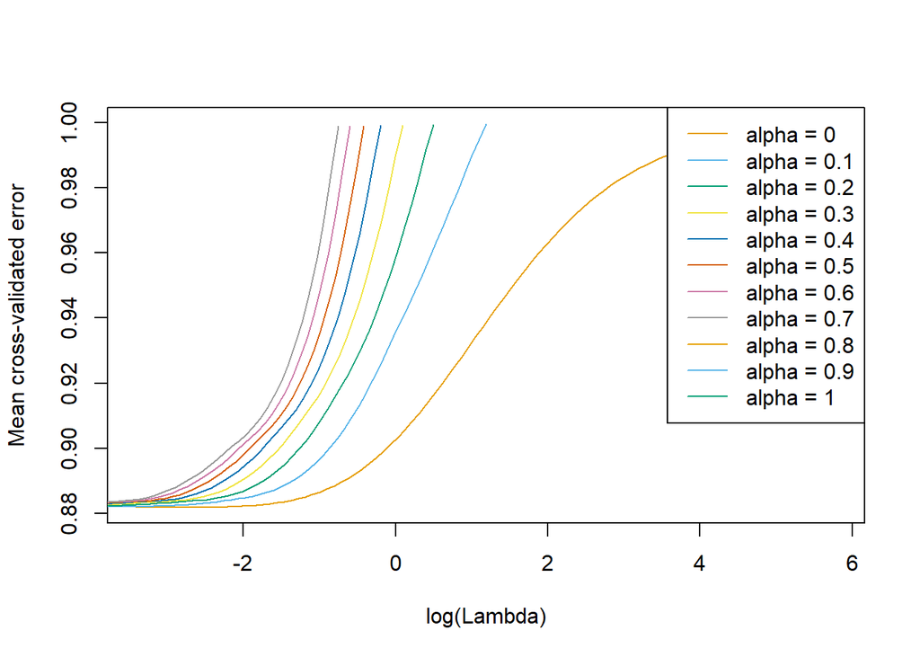

## Plot predictions

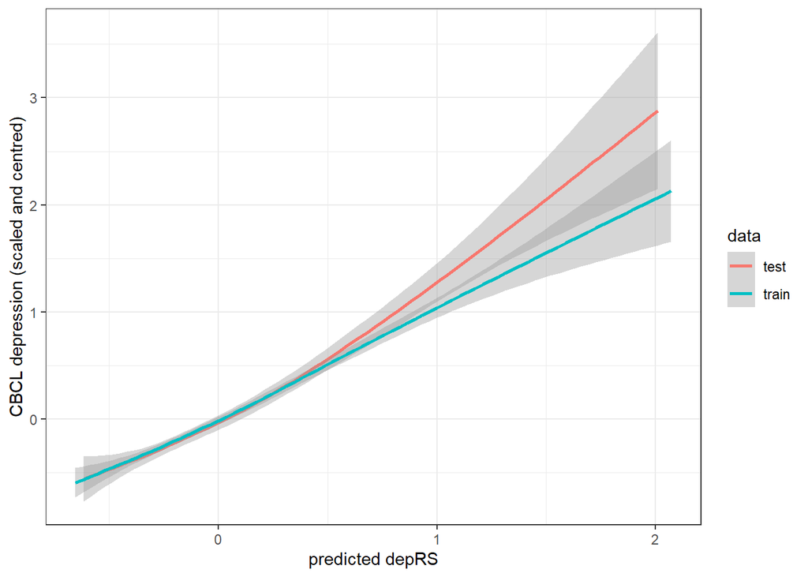

## R-square

|  | test |  |  | train |  |  | whole |  |  |
| --- | --- | --- | --- | --- | --- | --- | --- | --- | --- |
| Predictors | Estimates | CI | p | Estimates | CI | p | Estimates | CI | p |
| (Intercept) | 0.01 | -0.04 – 0.05 | 0.801 | -0.00 | -0.02 – 0.02 | 1.000 | 0.00 | -0.02 – 0.02 | 0.920 |
| lambda min | 1.15 | 1.02 – 1.29 | **<0.001** | 1.01 | 0.94 – 1.08 | **<0.001** | 1.04 | 0.98 – 1.10 | **<0.001** |
| Observations | 1408 |  |  | 5625 |  |  | 7033 |  |  |
| R<sup>2</sup> / R<sup>2</sup> adjusted | 0.165 / 0.164 |  |  | 0.129 / 0.129 |  |  | 0.136 / 0.136 |  |  |

# CBCL internalising subscale

## Cross-validation

|  | train_mse | test_mse |
| --- | --- | --- |
| alpha_0 | 0.8567425 | 0.8094785 |
| alpha_0.1 | 0.8581682 | 0.8135755 |
| alpha_0.2 | 0.8584766 | 0.8136005 |
| alpha_0.3 | 0.8585911 | 0.8134355 |
| alpha_0.4 | 0.8584743 | 0.8129395 |
| alpha_0.5 | 0.8584109 | 0.8126453 |
| alpha_0.6 | 0.8583715 | 0.8124507 |
| alpha_0.7 | 0.8583448 | 0.8123125 |
| alpha_0.8 | 0.8583256 | 0.8122093 |
| alpha_0.9 | 0.8583112 | 0.8121292 |
| alpha_1 | 0.8582999 | 0.8120654 |

Alpha ranges from 0 (ridge regression) to 1 (LASSO)

Alpha value with the lowest MSE in training sample = alpha_0. Coefficients from this model will be used.

## Plot alphas

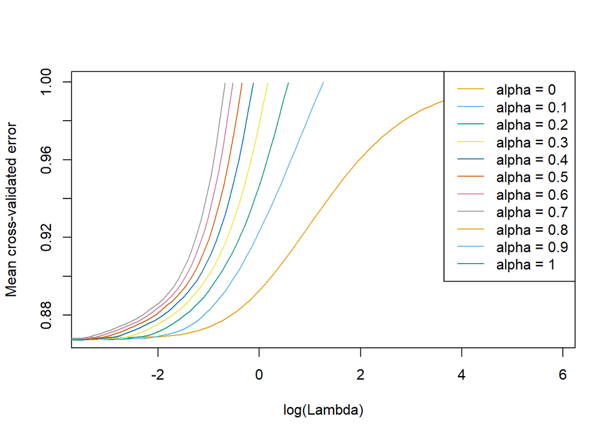

## Plot predictions

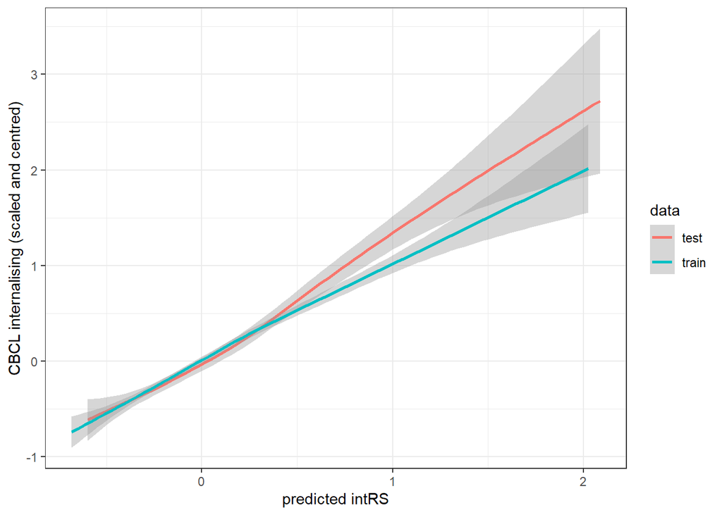

## R-square

|  | test |  |  | train |  |  | whole |  |  |
| --- | --- | --- | --- | --- | --- | --- | --- | --- | --- |
| Predictors | Estimates | CI | p | Estimates | CI | p | Estimates | CI | p |
| (Intercept) | 0.01 | -0.04 – 0.05 | 0.821 | -0.00 | -0.02 – 0.02 | 1.000 | 0.00 | -0.02 – 0.02 | 0.931 |
| lambda min | 1.24 | 1.11 – 1.37 | **<0.001** | 1.06 | 0.99 – 1.13 | **<0.001** | 1.10 | 1.03 – 1.16 | **<0.001** |
| Observations | 1408 |  |  | 5625 |  |  | 7033 |  |  |
| R<sup>2</sup> / R<sup>2</sup> adjusted | 0.197 / 0.197 |  |  | 0.144 / 0.143 |  |  | 0.154 / 0.154 |  |  |

# Coefficients

## CBCL depression

| preds | depRS |
| --- | --- |
| p_depression | 0.301 |
| emot_abuse | 0.274 |
| witness_dv | 0.205 |
| p_abuse | 0.128 |
| weightcontrol_ksads | 0.118 |
| s_abuse | 0.095 |
| serious_accident | 0.083 |
| death_loved_one | 0.060 |
| agemths | 0.043 |
| birthsex | 0.025 |
| income | 0.022 |
| fam_conflict | 0.021 |
| bmi | 0.017 |
| needed_food | 0.006 |
| parent_ed | -0.005 |
| comm_safety | -0.018 |
| days_active | -0.018 |
| area_depriv | -0.026 |
| p_acceptance | -0.032 |
| p_monitoring | -0.040 |
| tobacco_puff | -0.056 |
| sleep_hrs | -0.067 |
| witness_comm_violence | -0.224 |
| (Intercept) | -0.458 |

## CBCL internalising

| preds | intRS |
| --- | --- |
| p_depression | 0.308 |
| emot_abuse | 0.307 |
| s_abuse | 0.244 |
| witness_dv | 0.195 |
| weightcontrol_ksads | 0.138 |
| p_abuse | 0.137 |
| serious_accident | 0.111 |
| death_loved_one | 0.098 |
| birthsex | 0.090 |
| tobacco_puff | 0.089 |
| agemths | 0.019 |
| fam_conflict | 0.008 |
| bmi | 0.008 |
| income | 0.007 |
| needed_food | -0.002 |
| parent_ed | -0.005 |
| days_active | -0.013 |
| p_acceptance | -0.013 |
| sleep_hrs | -0.015 |
| p_monitoring | -0.034 |
| area_depriv | -0.036 |
| comm_safety | -0.036 |
| witness_comm_violence | -0.234 |
| (Intercept) | -1.194 |

# Descriptives

## Whole sample

Data Frame Summary

sumdat

**Dimensions**: 7033 x 42  
**Duplicates**: 0

| **Variable** | **Stats / Values** | **Freqs (% of Valid)** | **Graph** | **Missing** |
| --- | --- | --- | --- | --- |
| eventname [factor] | 1. baseline_year_1_arm_1 | 7033 ( 100.0% ) |  | 0 (0.0%) |
| tlfb_cal_scr_alc_ud [integer] | Min : 1 Mean : 1.2 Max : 3 | 1 : 8 ( 88.9% ) 3 : 1 ( 11.1% ) |  | 7024 (99.9%) |
| tlfb_cal_scr_alc_max [numeric] | Mean (sd) : 0.8 (0.6) min ≤ med ≤ max: 0 ≤ 1 ≤ 2 IQR (CV) : 0.7 (0.8) | 6 distinct values |  | 7023 (99.9%) |
| tlfb_cal_scr_num_events [integer] | Mean (sd) : 2.2 (4.8) min ≤ med ≤ max: 0 ≤ 1 ≤ 25 IQR (CV) : 2 (2.2) | 0 : 8 ( 28.6% ) 1 : 12 ( 42.9% ) 2 : 4 ( 14.3% ) 3 : 1 ( 3.6% ) 5 : 1 ( 3.6% ) 8 : 1 ( 3.6% ) 25 : 1 ( 3.6% ) |  | 7005 (99.6%) |
| illicit [factor] | 1. 0 2. 1 | 7031 ( 100.0% ) 2 ( 0.0% ) |  | 0 (0.0%) |
| tlfb_tob_puff [factor] | 1. 0 2. 1 | 6988 ( 99.4% ) 45 ( 0.6% ) |  | 0 (0.0%) |
| ksads_13_72_p [factor] | 1. 0 2. 1 | 6854 ( 97.5% ) 179 ( 2.5% ) |  | 0 (0.0%) |
| ksads_ptsd_raw_760_p [factor] | 1. 0 2. 1 | 6975 ( 99.2% ) 58 ( 0.8% ) |  | 0 (0.0%) |
| ksads_ptsd_raw_770_p [factor] | 1. 0 2. 1 | 5341 ( 75.9% ) 1692 ( 24.1% ) |  | 0 (0.0%) |
| ksads_ptsd_raw_766_p [factor] | 1. 0 2. 1 | 6492 ( 92.3% ) 541 ( 7.7% ) |  | 0 (0.0%) |
| sa [factor] | 1. 0 2. 1 | 6897 ( 98.1% ) 136 ( 1.9% ) |  | 0 (0.0%) |
| pa [factor] | 1. 0 2. 1 | 6970 ( 99.1% ) 63 ( 0.9% ) |  | 0 (0.0%) |
| ea [factor] | 1. 0 2. 1 | 6965 ( 99.0% ) 68 ( 1.0% ) |  | 0 (0.0%) |
| serious_accident [factor] | 1. 0 2. 1 | 6494 ( 92.3% ) 539 ( 7.7% ) |  | 0 (0.0%) |
| sleep_hrs [ordered, factor] | 1. <5hrs 2. 5-7hrs 3. 7-8hrs 4. 8-9hrs 5. 9+hrs | 17 ( 0.2% ) 183 ( 2.6% ) 783 ( 11.1% ) 2514 ( 35.7% ) 3536 ( 50.3% ) |  | 0 (0.0%) |
| bmi [numeric] | Mean (sd) : 18.7 (4) min ≤ med ≤ max: 9.8 ≤ 17.6 ≤ 53.9 IQR (CV) : 4.5 (0.2) | 4932 distinct values |  | 0 (0.0%) |
| needed_food [integer] | Min : 0 Mean : 0.1 Max : 1 | 0 : 6526 ( 92.8% ) 1 : 507 ( 7.2% ) |  | 0 (0.0%) |
| income [integer] | Mean (sd) : 7.4 (2.3) min ≤ med ≤ max: 1 ≤ 8 ≤ 10 IQR (CV) : 3 (0.3) | 1 : 202 ( 2.9% ) 2 : 236 ( 3.4% ) 3 : 152 ( 2.2% ) 4 : 293 ( 4.2% ) 5 : 405 ( 5.8% ) 6 : 594 ( 8.4% ) 7 : 981 ( 13.9% ) 8 : 1081 ( 15.4% ) 9 : 2252 ( 32.0% ) 10 : 837 ( 11.9% ) |  | 0 (0.0%) |
| parent_ed [factor] | 1. Bachelor 2. HS/GED 3. less_HS 4. Postgraduate 5. Some_College | 2133 ( 30.3% ) 641 ( 9.1% ) 282 ( 4.0% ) 2011 ( 28.6% ) 1966 ( 28.0% ) |  | 0 (0.0%) |
| birthsex [factor] | 1. M 2. F 3. Intersex | 3735 ( 53.1% ) 3298 ( 46.9% ) 0 ( 0.0% ) |  | 0 (0.0%) |
| gender_id [factor] | 1. M 2. F 3. Mtrans 4. Ftrans 5. GNC 6. Diff | 3729 ( 53.0% ) 3296 ( 46.9% ) 1 ( 0.0% ) 3 ( 0.0% ) 1 ( 0.0% ) 3 ( 0.0% ) |  | 0 (0.0%) |
| gender [factor] | 1. F 2. GNC 3. M | 3299 ( 46.9% ) 4 ( 0.1% ) 3730 ( 53.0% ) |  | 0 (0.0%) |
| race_ethnicity [factor] | 1. White 2. Black 3. Hispanic 4. Asian 5. Other | 3995 ( 56.8% ) 845 ( 12.0% ) 1273 ( 18.1% ) 151 ( 2.1% ) 769 ( 10.9% ) |  | 0 (0.0%) |
| reshist_addr1_adi_perc [integer] | Mean (sd) : 38.4 (26.2) min ≤ med ≤ max: 1 ≤ 32 ≤ 100 IQR (CV) : 36 (0.7) | 100 distinct values |  | 0 (0.0%) |
| nsc_p_ss_mean_3_items [numeric] | Mean (sd) : 3.9 (0.9) min ≤ med ≤ max: 1 ≤ 4 ≤ 5 IQR (CV) : 1.3 (0.2) | 16 distinct values |  | 0 (0.0%) |
| physical_activity1_y [integer] | Mean (sd) : 3.6 (2.3) min ≤ med ≤ max: 0 ≤ 3 ≤ 7 IQR (CV) : 3 (0.6) | 0 : 782 ( 11.1% ) 1 : 801 ( 11.4% ) 2 : 951 ( 13.5% ) 3 : 1011 ( 14.4% ) 4 : 782 ( 11.1% ) 5 : 969 ( 13.8% ) 6 : 528 ( 7.5% ) 7 : 1209 ( 17.2% ) |  | 0 (0.0%) |
| fes_y_ss_fc_pr [numeric] | Mean (sd) : 2 (1.9) min ≤ med ≤ max: 0 ≤ 1 ≤ 9 IQR (CV) : 3 (1) | 11 distinct values |  | 0 (0.0%) |
| pmq_y_ss_mean [numeric] | Mean (sd) : 4.4 (0.5) min ≤ med ≤ max: 1.8 ≤ 4.6 ≤ 5 IQR (CV) : 0.6 (0.1) | 18 distinct values |  | 0 (0.0%) |
| crpbi_y_ss_parent [numeric] | Mean (sd) : 2.8 (0.3) min ≤ med ≤ max: 1 ≤ 2.8 ≤ 3 IQR (CV) : 0.4 (0.1) | 11 distinct values |  | 0 (0.0%) |
| asr_scr_depress_r [integer] | Mean (sd) : 4 (3.6) min ≤ med ≤ max: 0 ≤ 3 ≤ 23 IQR (CV) : 5 (0.9) | 24 distinct values |  | 0 (0.0%) |
| site_id_l [character] | 1. site16 2. site04 3. site13 4. site06 5. site10 6. site17 7. site20 8. site12 9. site21 10. site03 [ 12 others ] | 705 ( 10.0% ) 504 ( 7.2% ) 483 ( 6.9% ) 441 ( 6.3% ) 415 ( 5.9% ) 415 ( 5.9% ) 376 ( 5.3% ) 342 ( 4.9% ) 327 ( 4.6% ) 319 ( 4.5% ) 2706 ( 38.5% ) |  | 0 (0.0%) |
| rel_family_id [integer] | Mean (sd) : 5879.1 (3479.3) min ≤ med ≤ max: 3 ≤ 5825 ≤ 11883 IQR (CV) : 6202 (0.6) | 7033 distinct values |  | 0 (0.0%) |
| rel_birth_id [character] | 1. (Empty string) 2. 10001 3. 100011 4. 100021 5. 100031 6. 100041 7. 100051 8. 100061 9. 1001 10. 100101 [ 7023 others ] | 1 ( 0.0% ) 1 ( 0.0% ) 1 ( 0.0% ) 1 ( 0.0% ) 1 ( 0.0% ) 1 ( 0.0% ) 1 ( 0.0% ) 1 ( 0.0% ) 1 ( 0.0% ) 1 ( 0.0% ) 7023 ( 99.9% ) |  | 0 (0.0%) |
| school_id [integer] | Mean (sd) : 62658.7 (34926.2) min ≤ med ≤ max: 0 ≤ 65147 ≤ 124308 IQR (CV) : 58832 (0.6) | 210 distinct values |  | 4775 (67.9%) |
| district_id [integer] | Mean (sd) : 8484.8 (5317.8) min ≤ med ≤ max: 124 ≤ 7923 ≤ 18543 IQR (CV) : 8634 (0.6) | 183 distinct values |  | 2941 (41.8%) |
| interview_date [character] | 1. 11/18/2017 2. 12/02/2017 3. 07/11/2017 4. 10/07/2017 5. 06/03/2017 6. 12/16/2017 7. 07/06/2017 8. 09/23/2017 9. 12/09/2017 10. 03/24/2018 [ 743 others ] | 31 ( 0.4% ) 31 ( 0.4% ) 30 ( 0.4% ) 28 ( 0.4% ) 27 ( 0.4% ) 27 ( 0.4% ) 26 ( 0.4% ) 24 ( 0.3% ) 24 ( 0.3% ) 23 ( 0.3% ) 6762 ( 96.1% ) |  | 0 (0.0%) |
| interview_age [integer] | Mean (sd) : 118.9 (7.4) min ≤ med ≤ max: 107 ≤ 119 ≤ 132 IQR (CV) : 13 (0.1) | 26 distinct values |  | 0 (0.0%) |
| visit_type [integer] | 1 distinct value | 1 : 7033 ( 100.0% ) |  | 0 (0.0%) |
| cbcl_scr_dsm5_depress_r [integer] | Mean (sd) : 1.5 (2.3) min ≤ med ≤ max: 0 ≤ 1 ≤ 22 IQR (CV) : 2 (1.5) | 20 distinct values |  | 0 (0.0%) |
| cbcl_scr_syn_internal_r [integer] | Mean (sd) : 5.1 (5.6) min ≤ med ≤ max: 0 ≤ 3 ≤ 50 IQR (CV) : 6 (1.1) | 42 distinct values |  | 0 (0.0%) |
| y2_age [numeric] | Mean (sd) : 12 (0.7) min ≤ med ≤ max: 10.6 ≤ 12 ≤ 14 IQR (CV) : 1.1 (0.1) | 41 distinct values |  | 0 (0.0%) |
| age_yrs [numeric] | Mean (sd) : 9.9 (0.6) min ≤ med ≤ max: 8.9 ≤ 9.9 ≤ 11 IQR (CV) : 1.1 (0.1) | 26 distinct values |  | 0 (0.0%) |

Generated by summarytools 1.0.1 ([R](https://www.r-project.org/) version 4.4.1)  
2025-03-17

## Training sample

Data Frame Summary

sumdat

**Dimensions**: 5625 x 42  
**Duplicates**: 0

| **Variable** | **Stats / Values** | **Freqs (% of Valid)** | **Graph** | **Missing** |
| --- | --- | --- | --- | --- |
| eventname [factor] | 1. baseline_year_1_arm_1 | 5625 ( 100.0% ) |  | 0 (0.0%) |
| tlfb_cal_scr_alc_ud [integer] | Min : 1 Mean : 1.3 Max : 3 | 1 : 6 ( 85.7% ) 3 : 1 ( 14.3% ) |  | 5618 (99.9%) |
| tlfb_cal_scr_alc_max [numeric] | Mean (sd) : 0.8 (0.7) min ≤ med ≤ max: 0 ≤ 1 ≤ 2 IQR (CV) : 0.8 (0.8) | 5 distinct values |  | 5617 (99.9%) |
| tlfb_cal_scr_num_events [integer] | Mean (sd) : 2.4 (5.3) min ≤ med ≤ max: 0 ≤ 1 ≤ 25 IQR (CV) : 2 (2.2) | 0 : 7 ( 30.4% ) 1 : 9 ( 39.1% ) 2 : 3 ( 13.0% ) 3 : 1 ( 4.3% ) 5 : 1 ( 4.3% ) 8 : 1 ( 4.3% ) 25 : 1 ( 4.3% ) |  | 5602 (99.6%) |
| illicit [factor] | 1. 0 2. 1 | 5624 ( 100.0% ) 1 ( 0.0% ) |  | 0 (0.0%) |
| tlfb_tob_puff [factor] | 1. 0 2. 1 | 5592 ( 99.4% ) 33 ( 0.6% ) |  | 0 (0.0%) |
| ksads_13_72_p [factor] | 1. 0 2. 1 | 5479 ( 97.4% ) 146 ( 2.6% ) |  | 0 (0.0%) |
| ksads_ptsd_raw_760_p [factor] | 1. 0 2. 1 | 5575 ( 99.1% ) 50 ( 0.9% ) |  | 0 (0.0%) |
| ksads_ptsd_raw_770_p [factor] | 1. 0 2. 1 | 4266 ( 75.8% ) 1359 ( 24.2% ) |  | 0 (0.0%) |
| ksads_ptsd_raw_766_p [factor] | 1. 0 2. 1 | 5183 ( 92.1% ) 442 ( 7.9% ) |  | 0 (0.0%) |
| sa [factor] | 1. 0 2. 1 | 5509 ( 97.9% ) 116 ( 2.1% ) |  | 0 (0.0%) |
| pa [factor] | 1. 0 2. 1 | 5575 ( 99.1% ) 50 ( 0.9% ) |  | 0 (0.0%) |
| ea [factor] | 1. 0 2. 1 | 5568 ( 99.0% ) 57 ( 1.0% ) |  | 0 (0.0%) |
| serious_accident [factor] | 1. 0 2. 1 | 5189 ( 92.2% ) 436 ( 7.8% ) |  | 0 (0.0%) |
| sleep_hrs [ordered, factor] | 1. <5hrs 2. 5-7hrs 3. 7-8hrs 4. 8-9hrs 5. 9+hrs | 14 ( 0.2% ) 154 ( 2.7% ) 636 ( 11.3% ) 2004 ( 35.6% ) 2817 ( 50.1% ) |  | 0 (0.0%) |
| bmi [numeric] | Mean (sd) : 18.7 (4.1) min ≤ med ≤ max: 9.8 ≤ 17.6 ≤ 45.6 IQR (CV) : 4.5 (0.2) | 4134 distinct values |  | 0 (0.0%) |
| needed_food [integer] | Min : 0 Mean : 0.1 Max : 1 | 0 : 5222 ( 92.8% ) 1 : 403 ( 7.2% ) |  | 0 (0.0%) |
| income [integer] | Mean (sd) : 7.4 (2.3) min ≤ med ≤ max: 1 ≤ 8 ≤ 10 IQR (CV) : 3 (0.3) | 1 : 162 ( 2.9% ) 2 : 193 ( 3.4% ) 3 : 121 ( 2.2% ) 4 : 237 ( 4.2% ) 5 : 333 ( 5.9% ) 6 : 467 ( 8.3% ) 7 : 784 ( 13.9% ) 8 : 858 ( 15.3% ) 9 : 1819 ( 32.3% ) 10 : 651 ( 11.6% ) |  | 0 (0.0%) |
| parent_ed [factor] | 1. Bachelor 2. HS/GED 3. less_HS 4. Postgraduate 5. Some_College | 1698 ( 30.2% ) 514 ( 9.1% ) 229 ( 4.1% ) 1605 ( 28.5% ) 1579 ( 28.1% ) |  | 0 (0.0%) |
| birthsex [factor] | 1. M 2. F 3. Intersex | 2990 ( 53.2% ) 2635 ( 46.8% ) 0 ( 0.0% ) |  | 0 (0.0%) |
| gender_id [factor] | 1. M 2. F 3. Mtrans 4. Ftrans 5. GNC 6. Diff | 2984 ( 53.0% ) 2634 ( 46.8% ) 1 ( 0.0% ) 3 ( 0.1% ) 0 ( 0.0% ) 3 ( 0.1% ) |  | 0 (0.0%) |
| gender [factor] | 1. F 2. GNC 3. M | 2637 ( 46.9% ) 3 ( 0.1% ) 2985 ( 53.1% ) |  | 0 (0.0%) |
| race_ethnicity [factor] | 1. White 2. Black 3. Hispanic 4. Asian 5. Other | 3197 ( 56.8% ) 702 ( 12.5% ) 1015 ( 18.0% ) 113 ( 2.0% ) 598 ( 10.6% ) |  | 0 (0.0%) |
| reshist_addr1_adi_perc [integer] | Mean (sd) : 38.6 (26.3) min ≤ med ≤ max: 1 ≤ 32 ≤ 100 IQR (CV) : 36 (0.7) | 100 distinct values |  | 0 (0.0%) |
| nsc_p_ss_mean_3_items [numeric] | Mean (sd) : 3.9 (0.9) min ≤ med ≤ max: 1 ≤ 4 ≤ 5 IQR (CV) : 1.3 (0.2) | 16 distinct values |  | 0 (0.0%) |
| physical_activity1_y [integer] | Mean (sd) : 3.6 (2.3) min ≤ med ≤ max: 0 ≤ 3 ≤ 7 IQR (CV) : 4 (0.6) | 0 : 620 ( 11.0% ) 1 : 646 ( 11.5% ) 2 : 752 ( 13.4% ) 3 : 822 ( 14.6% ) 4 : 615 ( 10.9% ) 5 : 758 ( 13.5% ) 6 : 421 ( 7.5% ) 7 : 991 ( 17.6% ) |  | 0 (0.0%) |
| fes_y_ss_fc_pr [numeric] | Mean (sd) : 2 (2) min ≤ med ≤ max: 0 ≤ 2 ≤ 9 IQR (CV) : 3 (1) | 11 distinct values |  | 0 (0.0%) |
| pmq_y_ss_mean [numeric] | Mean (sd) : 4.4 (0.5) min ≤ med ≤ max: 1.8 ≤ 4.6 ≤ 5 IQR (CV) : 0.6 (0.1) | 18 distinct values |  | 0 (0.0%) |
| crpbi_y_ss_parent [numeric] | Mean (sd) : 2.8 (0.3) min ≤ med ≤ max: 1 ≤ 2.8 ≤ 3 IQR (CV) : 0.4 (0.1) | 11 distinct values |  | 0 (0.0%) |
| asr_scr_depress_r [integer] | Mean (sd) : 4 (3.6) min ≤ med ≤ max: 0 ≤ 3 ≤ 22 IQR (CV) : 5 (0.9) | 23 distinct values |  | 0 (0.0%) |
| site_id_l [character] | 1. site16 2. site04 3. site13 4. site06 5. site10 6. site17 7. site20 8. site12 9. site09 10. site03 [ 12 others ] | 560 ( 10.0% ) 400 ( 7.1% ) 381 ( 6.8% ) 344 ( 6.1% ) 342 ( 6.1% ) 337 ( 6.0% ) 315 ( 5.6% ) 282 ( 5.0% ) 254 ( 4.5% ) 252 ( 4.5% ) 2158 ( 38.4% ) |  | 0 (0.0%) |
| rel_family_id [integer] | Mean (sd) : 5849.3 (3491.4) min ≤ med ≤ max: 3 ≤ 5787 ≤ 11883 IQR (CV) : 6251 (0.6) | 5625 distinct values |  | 0 (0.0%) |
| rel_birth_id [character] | 1. 10001 2. 100011 3. 100021 4. 100041 5. 100051 6. 100061 7. 1001 8. 100101 9. 100121 10. 100151 [ 5615 others ] | 1 ( 0.0% ) 1 ( 0.0% ) 1 ( 0.0% ) 1 ( 0.0% ) 1 ( 0.0% ) 1 ( 0.0% ) 1 ( 0.0% ) 1 ( 0.0% ) 1 ( 0.0% ) 1 ( 0.0% ) 5615 ( 99.8% ) |  | 0 (0.0%) |
| school_id [integer] | Mean (sd) : 62859.5 (34938.6) min ≤ med ≤ max: 0 ≤ 65847.5 ≤ 124308 IQR (CV) : 58576 (0.6) | 208 distinct values |  | 3787 (67.3%) |
| district_id [integer] | Mean (sd) : 8472.2 (5293.3) min ≤ med ≤ max: 124 ≤ 7923 ≤ 18543 IQR (CV) : 8202 (0.6) | 178 distinct values |  | 2337 (41.5%) |
| interview_date [character] | 1. 12/02/2017 2. 07/11/2017 3. 10/07/2017 4. 06/03/2017 5. 11/18/2017 6. 06/17/2017 7. 09/23/2017 8. 12/16/2017 9. 04/21/2018 10. 07/06/2017 [ 735 others ] | 26 ( 0.5% ) 25 ( 0.4% ) 24 ( 0.4% ) 22 ( 0.4% ) 22 ( 0.4% ) 21 ( 0.4% ) 21 ( 0.4% ) 21 ( 0.4% ) 20 ( 0.4% ) 20 ( 0.4% ) 5403 ( 96.1% ) |  | 0 (0.0%) |
| interview_age [integer] | Mean (sd) : 118.8 (7.4) min ≤ med ≤ max: 107 ≤ 119 ≤ 132 IQR (CV) : 13 (0.1) | 26 distinct values |  | 0 (0.0%) |
| visit_type [integer] | 1 distinct value | 1 : 5625 ( 100.0% ) |  | 0 (0.0%) |
| cbcl_scr_dsm5_depress_r [integer] | Mean (sd) : 1.5 (2.3) min ≤ med ≤ max: 0 ≤ 1 ≤ 22 IQR (CV) : 2 (1.5) | 19 distinct values |  | 0 (0.0%) |
| cbcl_scr_syn_internal_r [integer] | Mean (sd) : 5 (5.6) min ≤ med ≤ max: 0 ≤ 3 ≤ 50 IQR (CV) : 6 (1.1) | 41 distinct values |  | 0 (0.0%) |
| y2_age [numeric] | Mean (sd) : 12 (0.7) min ≤ med ≤ max: 10.6 ≤ 12 ≤ 13.8 IQR (CV) : 1 (0.1) | 39 distinct values |  | 0 (0.0%) |
| age_yrs [numeric] | Mean (sd) : 9.9 (0.6) min ≤ med ≤ max: 8.9 ≤ 9.9 ≤ 11 IQR (CV) : 1.1 (0.1) | 26 distinct values |  | 0 (0.0%) |

Generated by summarytools 1.0.1 ([R](https://www.r-project.org/) version 4.4.1)  
2025-03-17

## Test sample

Data Frame Summary

sumdat

**Dimensions**: 1408 x 42  
**Duplicates**: 0

| **Variable** | **Stats / Values** | **Freqs (% of Valid)** | **Graph** | **Missing** |
| --- | --- | --- | --- | --- |
| eventname [factor] | 1. baseline_year_1_arm_1 | 1408 ( 100.0% ) |  | 0 (0.0%) |
| tlfb_cal_scr_alc_ud [integer] | 1 distinct value | 1 : 2 ( 100.0% ) |  | 1406 (99.9%) |
| tlfb_cal_scr_alc_max [numeric] | Min : 0.5 Mean : 0.8 Max : 1 | 2 distinct values |  | 1406 (99.9%) |
| tlfb_cal_scr_num_events [integer] | Mean (sd) : 1 (0.7) min ≤ med ≤ max: 0 ≤ 1 ≤ 2 IQR (CV) : 0 (0.7) | 0 : 1 ( 20.0% ) 1 : 3 ( 60.0% ) 2 : 1 ( 20.0% ) |  | 1403 (99.6%) |
| illicit [factor] | 1. 0 2. 1 | 1407 ( 99.9% ) 1 ( 0.1% ) |  | 0 (0.0%) |
| tlfb_tob_puff [factor] | 1. 0 2. 1 | 1396 ( 99.1% ) 12 ( 0.9% ) |  | 0 (0.0%) |
| ksads_13_72_p [factor] | 1. 0 2. 1 | 1375 ( 97.7% ) 33 ( 2.3% ) |  | 0 (0.0%) |
| ksads_ptsd_raw_760_p [factor] | 1. 0 2. 1 | 1400 ( 99.4% ) 8 ( 0.6% ) |  | 0 (0.0%) |
| ksads_ptsd_raw_770_p [factor] | 1. 0 2. 1 | 1075 ( 76.3% ) 333 ( 23.7% ) |  | 0 (0.0%) |
| ksads_ptsd_raw_766_p [factor] | 1. 0 2. 1 | 1309 ( 93.0% ) 99 ( 7.0% ) |  | 0 (0.0%) |
| sa [factor] | 1. 0 2. 1 | 1388 ( 98.6% ) 20 ( 1.4% ) |  | 0 (0.0%) |
| pa [factor] | 1. 0 2. 1 | 1395 ( 99.1% ) 13 ( 0.9% ) |  | 0 (0.0%) |
| ea [factor] | 1. 0 2. 1 | 1397 ( 99.2% ) 11 ( 0.8% ) |  | 0 (0.0%) |
| serious_accident [factor] | 1. 0 2. 1 | 1305 ( 92.7% ) 103 ( 7.3% ) |  | 0 (0.0%) |
| sleep_hrs [ordered, factor] | 1. <5hrs 2. 5-7hrs 3. 7-8hrs 4. 8-9hrs 5. 9+hrs | 3 ( 0.2% ) 29 ( 2.1% ) 147 ( 10.4% ) 510 ( 36.2% ) 719 ( 51.1% ) |  | 0 (0.0%) |
| bmi [numeric] | Mean (sd) : 18.7 (4) min ≤ med ≤ max: 11.1 ≤ 17.6 ≤ 53.9 IQR (CV) : 4.4 (0.2) | 1228 distinct values |  | 0 (0.0%) |
| needed_food [integer] | Min : 0 Mean : 0.1 Max : 1 | 0 : 1304 ( 92.6% ) 1 : 104 ( 7.4% ) |  | 0 (0.0%) |
| income [integer] | Mean (sd) : 7.4 (2.3) min ≤ med ≤ max: 1 ≤ 8 ≤ 10 IQR (CV) : 3 (0.3) | 1 : 40 ( 2.8% ) 2 : 43 ( 3.1% ) 3 : 31 ( 2.2% ) 4 : 56 ( 4.0% ) 5 : 72 ( 5.1% ) 6 : 127 ( 9.0% ) 7 : 197 ( 14.0% ) 8 : 223 ( 15.8% ) 9 : 433 ( 30.8% ) 10 : 186 ( 13.2% ) |  | 0 (0.0%) |
| parent_ed [factor] | 1. Bachelor 2. HS/GED 3. less_HS 4. Postgraduate 5. Some_College | 435 ( 30.9% ) 127 ( 9.0% ) 53 ( 3.8% ) 406 ( 28.8% ) 387 ( 27.5% ) |  | 0 (0.0%) |
| birthsex [factor] | 1. M 2. F 3. Intersex | 745 ( 52.9% ) 663 ( 47.1% ) 0 ( 0.0% ) |  | 0 (0.0%) |
| gender_id [factor] | 1. M 2. F 3. Mtrans 4. Ftrans 5. GNC 6. Diff | 745 ( 52.9% ) 662 ( 47.0% ) 0 ( 0.0% ) 0 ( 0.0% ) 1 ( 0.1% ) 0 ( 0.0% ) |  | 0 (0.0%) |
| gender [factor] | 1. F 2. GNC 3. M | 662 ( 47.0% ) 1 ( 0.1% ) 745 ( 52.9% ) |  | 0 (0.0%) |
| race_ethnicity [factor] | 1. White 2. Black 3. Hispanic 4. Asian 5. Other | 798 ( 56.7% ) 143 ( 10.2% ) 258 ( 18.3% ) 38 ( 2.7% ) 171 ( 12.1% ) |  | 0 (0.0%) |
| reshist_addr1_adi_perc [integer] | Mean (sd) : 37.7 (25.9) min ≤ med ≤ max: 1 ≤ 31 ≤ 100 IQR (CV) : 34 (0.7) | 100 distinct values |  | 0 (0.0%) |
| nsc_p_ss_mean_3_items [numeric] | Mean (sd) : 4 (0.9) min ≤ med ≤ max: 1 ≤ 4 ≤ 5 IQR (CV) : 1.3 (0.2) | 13 distinct values |  | 0 (0.0%) |
| physical_activity1_y [integer] | Mean (sd) : 3.6 (2.3) min ≤ med ≤ max: 0 ≤ 3 ≤ 7 IQR (CV) : 3 (0.6) | 0 : 162 ( 11.5% ) 1 : 155 ( 11.0% ) 2 : 199 ( 14.1% ) 3 : 189 ( 13.4% ) 4 : 167 ( 11.9% ) 5 : 211 ( 15.0% ) 6 : 107 ( 7.6% ) 7 : 218 ( 15.5% ) |  | 0 (0.0%) |
| fes_y_ss_fc_pr [numeric] | Mean (sd) : 1.9 (1.9) min ≤ med ≤ max: 0 ≤ 1 ≤ 9 IQR (CV) : 3 (1) | 0 : 420 ( 29.8% ) 1 : 333 ( 23.7% ) 2 : 226 ( 16.1% ) 3 : 143 ( 10.2% ) 4 : 122 ( 8.7% ) 5 : 74 ( 5.3% ) 6 : 49 ( 3.5% ) 7 : 34 ( 2.4% ) 8 : 5 ( 0.4% ) 9 : 2 ( 0.1% ) |  | 0 (0.0%) |
| pmq_y_ss_mean [numeric] | Mean (sd) : 4.4 (0.5) min ≤ med ≤ max: 2.2 ≤ 4.4 ≤ 5 IQR (CV) : 0.6 (0.1) | 15 distinct values |  | 0 (0.0%) |
| crpbi_y_ss_parent [numeric] | Mean (sd) : 2.8 (0.3) min ≤ med ≤ max: 1 ≤ 3 ≤ 3 IQR (CV) : 0.4 (0.1) | 11 distinct values |  | 0 (0.0%) |
| asr_scr_depress_r [integer] | Mean (sd) : 4.1 (3.7) min ≤ med ≤ max: 0 ≤ 3 ≤ 23 IQR (CV) : 5 (0.9) | 23 distinct values |  | 0 (0.0%) |
| site_id_l [character] | 1. site16 2. site04 3. site13 4. site06 5. site17 6. site21 7. site10 8. site03 9. site18 10. site11 [ 12 others ] | 145 ( 10.3% ) 104 ( 7.4% ) 102 ( 7.2% ) 97 ( 6.9% ) 78 ( 5.5% ) 75 ( 5.3% ) 73 ( 5.2% ) 67 ( 4.8% ) 66 ( 4.7% ) 61 ( 4.3% ) 540 ( 38.4% ) |  | 0 (0.0%) |
| rel_family_id [integer] | Mean (sd) : 5998.2 (3429) min ≤ med ≤ max: 5 ≤ 6026 ≤ 11866 IQR (CV) : 6037.2 (0.6) | 1408 distinct values |  | 0 (0.0%) |
| rel_birth_id [character] | 1. (Empty string) 2. 100031 3. 10011 4. 100251 5. 100301 6. 10031 7. 100311 8. 100371 9. 100411 10. 100471 [ 1398 others ] | 1 ( 0.1% ) 1 ( 0.1% ) 1 ( 0.1% ) 1 ( 0.1% ) 1 ( 0.1% ) 1 ( 0.1% ) 1 ( 0.1% ) 1 ( 0.1% ) 1 ( 0.1% ) 1 ( 0.1% ) 1398 ( 99.3% ) |  | 0 (0.0%) |
| school_id [integer] | Mean (sd) : 61779.8 (34899.9) min ≤ med ≤ max: 0 ≤ 61111 ≤ 124288 IQR (CV) : 57411 (0.6) | 169 distinct values |  | 988 (70.2%) |
| district_id [integer] | Mean (sd) : 8536.4 (5419.7) min ≤ med ≤ max: 124 ≤ 7923 ≤ 18487 IQR (CV) : 8826 (0.6) | 136 distinct values |  | 604 (42.9%) |
| interview_date [character] | 1. 11/18/2017 2. 11/20/2017 3. 04/03/2018 4. 06/12/2017 5. 10/20/2017 6. 02/17/2018 7. 03/03/2018 8. 07/20/2017 9. 08/03/2017 10. 01/06/2018 [ 591 others ] | 9 ( 0.6% ) 9 ( 0.6% ) 8 ( 0.6% ) 8 ( 0.6% ) 8 ( 0.6% ) 7 ( 0.5% ) 7 ( 0.5% ) 7 ( 0.5% ) 7 ( 0.5% ) 6 ( 0.4% ) 1332 ( 94.6% ) |  | 0 (0.0%) |
| interview_age [integer] | Mean (sd) : 119.1 (7.5) min ≤ med ≤ max: 107 ≤ 119 ≤ 132 IQR (CV) : 14 (0.1) | 26 distinct values |  | 0 (0.0%) |
| visit_type [integer] | 1 distinct value | 1 : 1408 ( 100.0% ) |  | 0 (0.0%) |
| cbcl_scr_dsm5_depress_r [integer] | Mean (sd) : 1.6 (2.5) min ≤ med ≤ max: 0 ≤ 1 ≤ 17 IQR (CV) : 2 (1.6) | 18 distinct values |  | 0 (0.0%) |
| cbcl_scr_syn_internal_r [integer] | Mean (sd) : 5.3 (5.9) min ≤ med ≤ max: 0 ≤ 4 ≤ 41 IQR (CV) : 6 (1.1) | 38 distinct values |  | 0 (0.0%) |
| y2_age [numeric] | Mean (sd) : 12 (0.7) min ≤ med ≤ max: 10.6 ≤ 12 ≤ 14 IQR (CV) : 1.1 (0.1) | 40 distinct values |  | 0 (0.0%) |
| age_yrs [numeric] | Mean (sd) : 9.9 (0.6) min ≤ med ≤ max: 8.9 ≤ 9.9 ≤ 11 IQR (CV) : 1.2 (0.1) | 26 distinct values |  | 0 (0.0%) |

Generated by summarytools 1.0.1 ([R](https://www.r-project.org/) version 4.4.1)  
2025-03-17